# infovis1

Ricardo gore

7/27/2018

## Preface

When I started coding for biology I realize on this amazing challenge about how to tell the history from a bunch of Next Generation sequencing datasets. Visualization of information (from massive data mining in special) become in a nice part of my data scientist training.

## Data Visualization

Please, read my outlines for the data visualization course in the the follow README file [here](https://github.com/RJEGR/July_2018_bioinfo) and deep in the knowlege of this advantage.

## Trainning dataset

We will use high throughput sequencing dataset from a marine non model organism exposed to hidrocarbon polutant. The libraries sequenced were acqured from undifferented (Un) and sexual differented stages ( Male and female). In this experiment time 0 and three corresponded to hidrocarbon pollutant expossition (before and after, respectivily).

Libraries were preprocessing using the standar parameters within trimmomatic and the assembly were performed with trinity. Differential gene expression and annotation were perform with edgeR (an R package) and Trinotate, respectivily.

The chunk-code here correspond to my workflow used in the lab. Hope you enjoy it!

## Loading input files

```r
dir <- c("/Users/cigom/Documents/GitHub/July_2018_bioinfo/infile/")
setwd(dir)
# x <- read.table(paste0(dir,"diffExpr.P1e-2_C1.matrix"))
```

And read the input file; then let’s make a `head(x)` from the file:

|  | T0F3 | T0F4 | T0M1 | T0M4 | T0UR | T0U |
| --- | --- | --- | --- | --- | --- | --- |
| TRINITY_DN29981_c0_g1_i1 | 158.162 | 152.974 | 0.537 | 0.000 | 0.000 | 0.000 |
| TRINITY_DN25178_c2_g1_i1 | 0.337 | 0.181 | 167.292 | 100.095 | 140.610 | 925.271 |
| TRINITY_DN23469_c2_g2_i1 | 0.000 | 0.000 | 24.217 | 0.000 | 312.915 | 3789.992 |
| TRINITY_DN27384_c1_g1_i1 | 54.064 | 150.841 | 0.000 | 0.000 | 0.000 | 0.095 |
| TRINITY_DN32136_c1_g1_i2 | 0.000 | 0.000 | 34.300 | 3.078 | 48.656 | 93.654 |
| TRINITY_DN24700_c1_g1_i3 | 0.000 | 0.000 | 2.190 | 0.000 | 50.995 | 2477.124 |

Let’s log2 transform the data

## Differential Expression

Continue ..:

### Heatmap

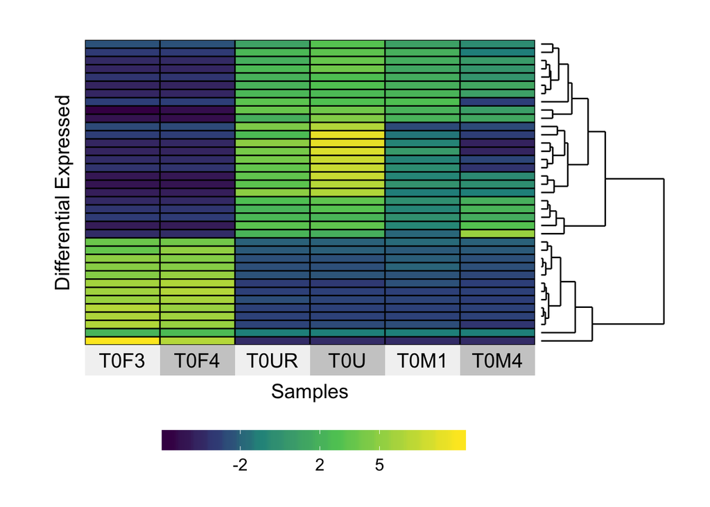

example 1

```r
library(superheat)
superheat(data,
          # retain original order of rows/cols
          pretty.order.rows = TRUE,
          pretty.order.cols = TRUE,
          row.dendrogram = TRUE,
          left.label = "none",
          bottom.label.text.angle = 0,
          row.title = "Differential Expressed",
          column.title = "Samples")
```

Continue…

### Volcano plot

After process the differential gene expression analysis (Ex. running the `run_DE_analysis.pl` from [Trinity framework](https://github.com/trinityrnaseq/trinityrnaseq/wiki/Trinity-Differential-Expression)) we can improve the data visualization as follow:

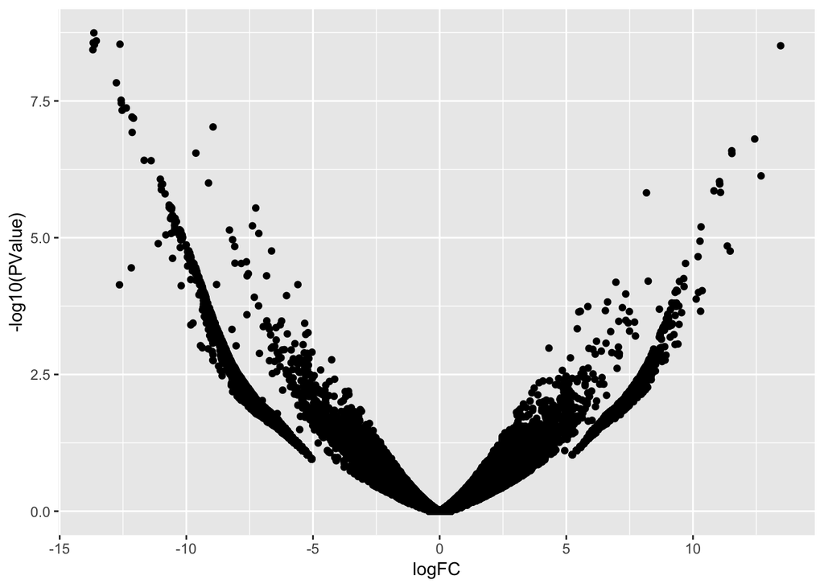

This is a Volcano plot

Let’s label by Fold Change (up/down) rate and significancy by the follow condition: - log Fold Change (logFC) > abs(2) - False Discovery Rate (FDR) < 0.05 - Both statements: FDR < 0.05 and logFC > abs(2)

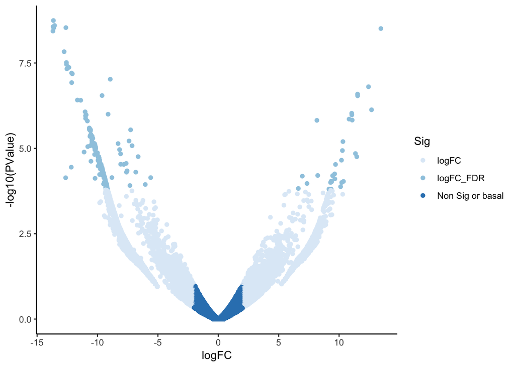

Volcano; Color and fill

```r
# logf>abs(2) fdr < 0.05 fdr < 0.05 and logfc> abs(2)
DE$Sig <- "Non Sig or basal"
DE$Sig[(abs(DE$logFC) > 2)] <- "logFC"
DE$Sig[(DE$FDR<0.05) & (abs(DE$logFC)>2)] <- "logFC_FDR"

p <- ggplot(DE, aes(x=logFC, y=-log10(PValue))) +
    geom_point(aes(color = Sig)) + theme_classic() +
    # RColorBrewer::display.brewer.all()
    scale_color_brewer()
p
```

Add lines and axis name:

```r
p1 <- p +
        geom_vline(xintercept = 0) +
        geom_hline(yintercept = 0) +
        geom_hline(yintercept = -log10(0.0001), linetype = "dashed") +
        geom_vline(xintercept = c(-2, 2), linetype = "dashed")
```

And also let’s rename x and y axis using backquote macros:

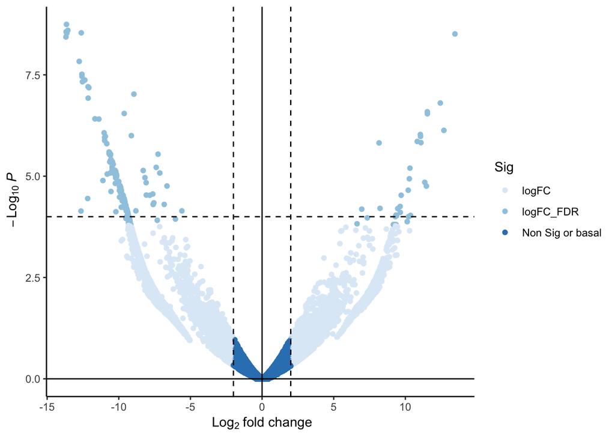

Volcano lines and axis labeled

```r
p1 + xlab(bquote(~Log[2]~ "fold change")) + ylab(bquote(~-Log[10]~italic(P)))
```

```r
# p2 <- p + xlab("Fold change (log2)") + ylab("P-Value")
```

Finally, let’s label the dots from the scatter:

```r
library(ggrepel)
maxlab <- max(-log10(DE$PValue)) - 1 # select the points below the highest -log10(PValue) value to label

p2 <-  p1 + geom_text_repel(
          data = subset(DE, -log10(PValue) > maxlab),
          aes(label = Sig),
          size = 2.5,
          box.padding = unit(0.2, "lines"),
          point.padding = unit(0.2, "lines")
  )
```

Finally, let’s compare the layouts:

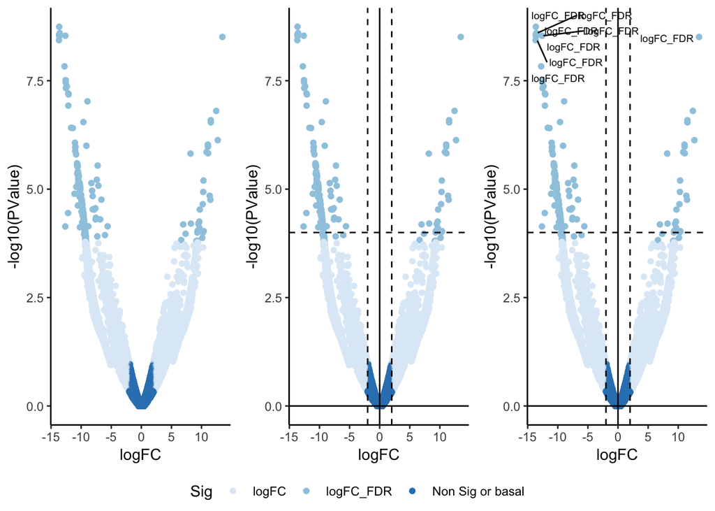

Volcano comparison

```r
library(gridExtra)
library(grid)
grid_arrange_shared_legend(p,p1,p2, ncol = 3)
```

## Functional and enrichment annotation

After assembly denovo or guided transcriptome is common to map each contig to a reference in order to annotate the potential source of each transcript. In this view, blast2go is the average tool used by users to perform this analysis nevertheles blast2go is a non free tool. In spite of, [Trinotate](https://github.com/Trinotate/Trinotate.github.io/wiki) is a useful free-framework to this purpose. Trinotate makes use of a number of different well referenced methods for functional annotation including homology search to known sequence data (BLAST+/SwissProt), protein domain identification (HMMER/PFAM), protein signal peptide and transmembrane domain prediction (signalP/tmHMM), and leveraging various annotation databases (eggNOG/GO/Kegg databases).

In personal experience, trinotate had resulted in better performance (such less computational time) than the blast2go counterpart and useful to automatically annotate one workflow at time.

In addition, trinotateR is package developed by **Chris Stubben** with useful functions to “wrangling” the tab-delimited `Trinotate.xls` result.

```r
library(trinotateR)
y <- read_trinotate(paste0(dir,"Trinotate.xls"))
knitr::kable(summary_trinotate(y))
```

|  | unique | total |
| --- | --- | --- |
| gene_id | 61694 | 148534 |
| transcript_id | 147454 | 148534 |
| prot_id | 55785 | 55785 |
| prot_coords | 24521 | 55785 |
| sprot_Top_BLASTX_hit | 43800 | 45692 |
| gene_ontology_blast | 14000 | 44709 |
| Kegg | 15112 | 39430 |
| eggnog | 5651 | 37535 |
| sprot_Top_BLASTP_hit | 28519 | 35660 |
| Pfam | 26217 | 34005 |
| gene_ontology_pfam | 1775 | 20111 |
| TmHMM | 7764 | 10393 |
| RNAMMER | 9 | 9 |
| SignalP | 0 | 0 |
| transcript | 0 | 0 |
| peptide | 0 | 0 |

```r
y1 <- split_pfam(y)
```

```
## 70856 Pfam annotations
```

```r
head(y1,3)[,c(2,4:7)]
```

```
##                  transcript    pfam         symbol
## 1: TRINITY_DN10004_c0_g1_i1 PF01442 Apolipoprotein
## 2: TRINITY_DN10005_c0_g1_i1 PF16489           GAIN
## 3: TRINITY_DN10007_c0_g1_i1 PF00135     COesterase
##                                           name  align
## 1:               Apolipoprotein A1/A4/E domain  20-67
## 2: GPCR-Autoproteolysis INducing (GAIN) domain 17-121
## 3:                     Carboxylesterase family   3-85
```

Finally, the `summary_pfam` lists both, the number of unique Pfam identifiers and the total genes, transcripts and proteins with a Pfam annotation.

```r
y2 <- summary_pfam(y1)
```

```
## 4849 rows
```

```r
head(y2[order(-y2$transcripts),])
```

```
##       pfam      symbol                       name genes transcripts
## 1: PF00386         C1q                 C1q domain   201         801
## 2: PF00069     Pkinase      Protein kinase domain   279         594
## 3: PF07714 Pkinase_Tyr    Protein tyrosine kinase   272         583
## 4: PF00400        WD40   WD domain, G-beta repeat   203         461
## 5: PF12796       Ank_2 Ankyrin repeats (3 copies)   219         455
## 6: PF00023         Ank             Ankyrin repeat   214         449
##    proteins total
## 1:      809   856
## 2:      594   611
## 3:      583   596
## 4:      461  1351
## 5:      455   925
## 6:      449  1031
```

The summary table also includes a count attribute with the number of unique genes, transcripts and proteins with a Pfam annotation, as well as the total number of annotations. In this example, there are 33,721 unique transcripts with a Pfam annotation and 56,642 total annotations to transcripts (since those may have more than one Pfam annotation).

```r
c <- attr(y2, "count")
print(c)
```

```
##             unique annotations
## Pfam          4849       70856
## genes        14417       25280
## transcripts  33721       56642
## proteins     34005       56757
```

Load the DataTables library to display and search within all the available genes/transcripts annotations.

```r
library(DT)
z <- data.frame(y2)
z$pfam <- paste0('<a href="http://pfam.xfam.org/family/', z$pfam, '">', z$pfam, '</a>')
datatable(z , escape=1, options = list( pageLength = 10 ) )
```

|  | pfam | symbol | name | genes | transcripts | proteins | total |
| --- | --- | --- | --- | --- | --- | --- | --- |
| 1 | PF00069 | Pkinase | Protein kinase domain | 279 | 594 | 594 | 611 |
| 2 | PF07714 | Pkinase_Tyr | Protein tyrosine kinase | 272 | 583 | 583 | 596 |
| 3 | PF12796 | Ank_2 | Ankyrin repeats (3 copies) | 219 | 455 | 455 | 925 |
| 4 | PF00023 | Ank | Ankyrin repeat | 214 | 449 | 449 | 1031 |
| 5 | PF00400 | WD40 | WD domain, G-beta repeat | 203 | 461 | 461 | 1351 |
| 6 | PF00386 | C1q | C1q domain | 201 | 801 | 809 | 856 |
| 7 | PF00096 | zf-C2H2 | Zinc finger, C2H2 type | 197 | 364 | 365 | 1070 |
| 8 | PF13637 | Ank_4 | Ankyrin repeats (many copies) | 194 | 424 | 424 | 875 |
| 9 | PF00001 | 7tm_1 | 7 transmembrane receptor (rhodopsin family) | 187 | 322 | 322 | 322 |
| 10 | PF13606 | Ank_3 | Ankyrin repeat | 177 | 364 | 364 | 627 |

[output cut: 4839 more lines]

```r
#renderDataTable(z , escape=1, options = list( pageLength = 10 ), server = TRUE )
```

Try `trinotateR` to get the Gene Ontology annotation. A GO annotation is a statement about the function of a particular gene. Each GO annotation consists of an association between a gene and a GO term. Together, these statements comprise a “snapshot” of current biological knowledge. The GO describes function with respect to three aspects: molecular function (molecular-level activities performed by gene products), cellular component (the locations relative to cellular structures in which a gene product performs a function), and biological process (the larger processes, or ‘biological programs’ accomplished by multiple molecular activities)

> Ref: http://www.geneontology.org/page/ontology-documentation.

```r
go <- split_GO(y)
```

```
## 473221 gene_ontology_blast annotations
```

```r
gos <- summary_GO(go)
```

```
## 15386 rows
```

```r
head(gos[order(-gos$transcripts),])
```

```
##            go           ontology                           name genes
## 1: GO:0005737 cellular_component                      cytoplasm  5087
## 2: GO:0005634 cellular_component                        nucleus  4286
## 3: GO:0016021 cellular_component integral component of membrane  3839
## 4: GO:0005829 cellular_component                        cytosol  3508
## 5: GO:0005886 cellular_component                plasma membrane  3366
## 6: GO:0046872 molecular_function              metal ion binding  2771
##    transcripts proteins total
## 1:       10521     8155 10550
## 2:        8687     6947  8725
## 3:        7817     6020  7832
## 4:        7300     5854  7325
## 5:        6305     4961  6315
## 6:        5815     4421  5829
```

And also determine the counts

```r
cgo <- attr(gos, "count")
print(cgo)
```

```
##             unique annotations
## GO           15386      473221
## genes        19818      241902
## transcripts  44415      472268
## proteins     34463      379068
```

Using only the translated transcripts to get the differential Expressed annotations:

|  | transcript | go | ontology | name | T0F3 | T0F4 | T0M1 | T0M4 | T0UR | T0U |
| --- | --- | --- | --- | --- | --- | --- | --- | --- | --- | --- |
| 1 | TRINITY_DN25178_c2_g1_i1 | GO:0030016 | cellular_component | myofibril | 0.337 | 0.181 | 167.292 | 100.095 | 140.61 | 925.271 |
| 2 | TRINITY_DN25178_c2_g1_i1 | GO:0032982 | cellular_component | myosin filament | 0.337 | 0.181 | 167.292 | 100.095 | 140.61 | 925.271 |
| 3 | TRINITY_DN25178_c2_g1_i1 | GO:0003774 | molecular_function | motor activity | 0.337 | 0.181 | 167.292 | 100.095 | 140.61 | 925.271 |
| 4 | TRINITY_DN25251_c1_g1_i2 | GO:0005887 | cellular_component | integral component of plasma membrane | 0 | 0 | 58.871 | 0 | 79.146 | 61.685 |
| 5 | TRINITY_DN25251_c1_g1_i2 | GO:0015297 | molecular_function | antiporter activity | 0 | 0 | 58.871 | 0 | 79.146 | 61.685 |
| 6 | TRINITY_DN25251_c1_g1_i2 | GO:0005452 | molecular_function | inorganic anion exchanger activity | 0 | 0 | 58.871 | 0 | 79.146 | 61.685 |
| 7 | TRINITY_DN25251_c1_g1_i2 | GO:0008510 | molecular_function | sodium:bicarbonate symporter activity | 0 | 0 | 58.871 | 0 | 79.146 | 61.685 |
| 8 | TRINITY_DN25251_c1_g1_i2 | GO:0007399 | biological_process | nervous system development | 0 | 0 | 58.871 | 0 | 79.146 | 61.685 |
| 9 | TRINITY_DN25251_c1_g1_i2 | GO:0051453 | biological_process | regulation of intracellular pH | 0 | 0 | 58.871 | 0 | 79.146 | 61.685 |
| 10 | TRINITY_DN27309_c0_g1_i1 | GO:0015629 | cellular_component | actin cytoskeleton | 0 | 0 | 64.133 | 47.143 | 74.586 | 134.619 |

[output cut: 161 more lines]

Let’s draw some visualizations from the annotation enrichment throught a the transcriptome assembly:

```r
library(ggpubr)
```

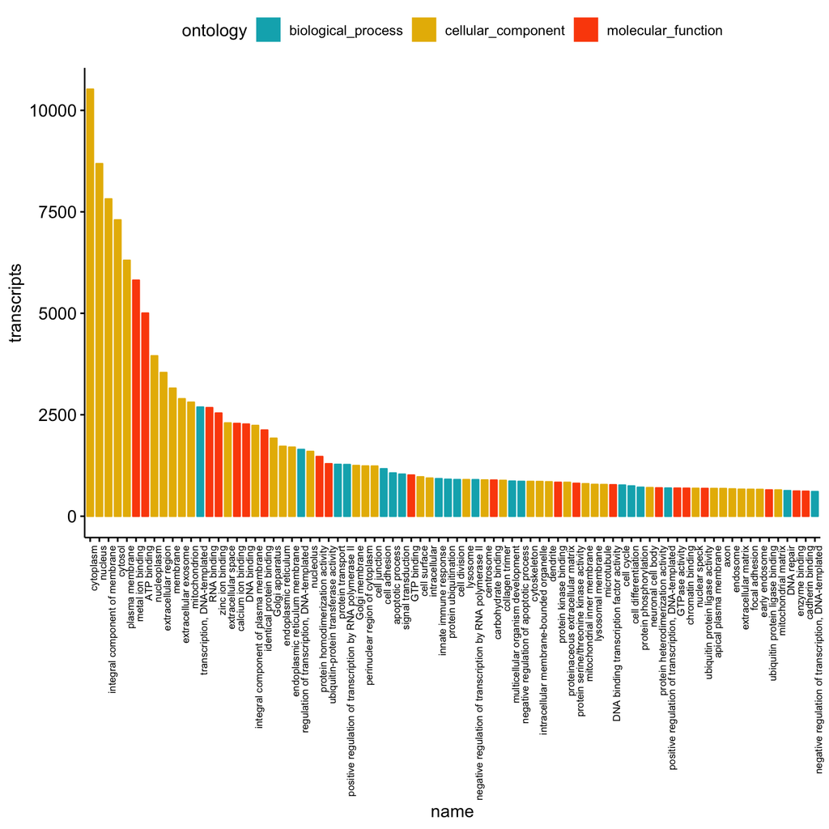

Gene Ontology enrichment plot (top 80 transcripts)

```r
plotgos <- head(gos[order(-gos$transcripts),], 80)
ggbarplot(plotgos, "name", "transcripts",
          fill = "ontology",
          color = "ontology",
   palette = c("#00AFBB", "#E7B800", "#FC4E07")) +
   theme(axis.text.x = element_text(angle = 90, hjust = 1, size = 7))
```

```r
   # facet_grid(ontology ~ .,) + theme(#strip.text.x = element_blank(),
   #                              axis.text.x = element_text(angle = 90, hjust = 1))
```

And separate the ontology annotation for further analysis:

| Var1 | Freq |
| --- | --- |
| biological_process | 10236 |
| cellular_component | 1571 |
| molecular_function | 3579 |

…

```r
MF <- gos[gos$ontology=="molecular_function",]
CC <- gos[gos$ontology=="cellular_component",]
BP <- gos[gos$ontology=="biological_process",]
```

## Semantic similarity (of GO terms)

Determine the similarity of two GO terms based on the annotation statistics of their common ancestor terms by computing semantic similarity among GO terms, sets of GO terms, gene products, and gene clusters, providing different methods than **measure** the information content (IC). To details please read the [Wang’s](https://academic.oup.com/bioinformatics/article/26/7/976/213143) paper published in Oxford.

First, build annotation data needed by GOSemSim via `godata` function. Based in figure from Gene Ontology Enrichment, we could focus on the Cellular component (CC) terms. install the human database by `source("https://bioconductor.org/biocLite.R"); (~ 74.3 MB) biocLite("org.Hs.eg.db"); library(org.Hs.eg.db)`

```r
library(GOSemSim)
hsGO <- godata('org.Hs.eg.db', ont="CC", computeIC=FALSE)
```

```
## preparing gene to GO mapping data...
```

```r
go <- as.vector(CC$go)
go1 <- sample(go, 20)
go2 <- sample(go, 20)
gosim <- mgoSim(go1, go2, semData=hsGO, measure="Wang", combine=NULL)
```

And visualize the similarity of the GO term.

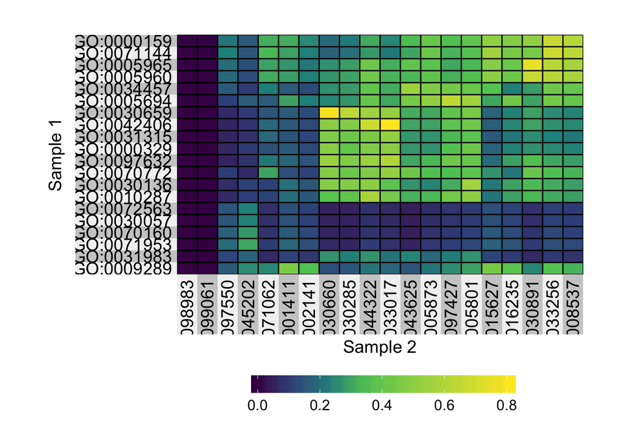

```r
superheat(gosim,
          # retain original order of rows/cols
          pretty.order.rows = TRUE,
          pretty.order.cols = TRUE,
          #left.label = "none",
          bottom.label.text.angle = 90,
          row.title = "Sample 1",
          column.title = "Sample 2"
          )
```